# Exploring Data

## Instagram influencer dataset exploring

channel info: Username in instagram

influence score: It is calculated based on their popularity.

posts: total posts they have

followers: total followers they have

avg_likes: average likes of their total posts

60_days_eng_rate: 60 days of engagement rate

new_post_avg_like: a calculation of the average likes they gained from new posts.

total_likes: total likes of their posts in instagram.

country: users' origin. What countries they from?

```python
from matplotlib import pyplot as plt
import seaborn as sns
import pandas as pd
import numpy as np
import warnings
warnings.filterwarnings('ignore')
```

```python
insta = pd.read_csv('/Users/yangyilin/Desktop/anly-501-project-YilinYang2000-1/data/00-raw-data/instagram_infl.csv')
insta.head()
```

|  | Unnamed: 0 | rank | channel_info | influence_score | posts(k) | followers(m) | X60_day_eng_rate(%) | new_post_avg_like(m) | total_likes(b) | country | avg_likes |
| --- | --- | --- | --- | --- | --- | --- | --- | --- | --- | --- | --- |
| 0 | 1 | 1 | cristiano | 92 | 3.30 | 475.8 | 1.39 | 6.5 | 29.0 | Spain | 8700000.0 |
| 1 | 2 | 2 | kyliejenner | 91 | 6.90 | 366.2 | 1.62 | 5.9 | 57.4 | United States | 8300000.0 |
| 2 | 3 | 3 | leomessi | 90 | 0.89 | 357.3 | 1.24 | 4.4 | 6.0 | Undefined | 6800000.0 |
| 3 | 4 | 4 | selenagomez | 93 | 1.80 | 342.7 | 0.97 | 3.3 | 11.5 | United States | 6200000.0 |
| 4 | 5 | 5 | therock | 91 | 6.80 | 334.1 | 0.20 | 665.3 | 12.5 | United States | 1900000.0 |

Firstly, I want to plot the distribution of instagram influencers' countries in order to further discuss what countries influencers are more popular among the world.

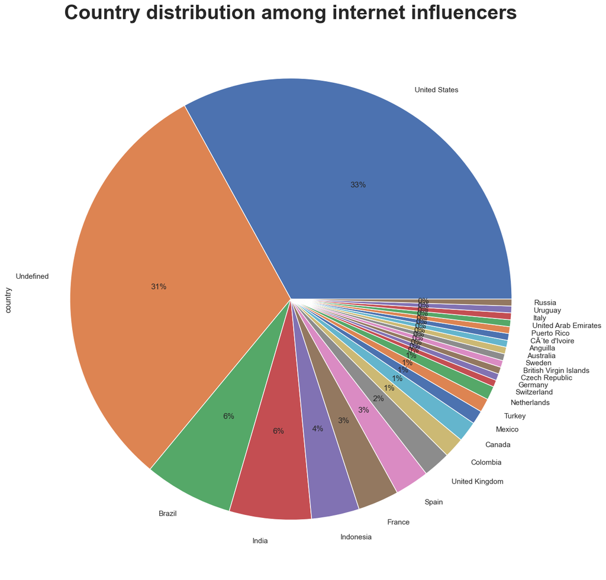

```python
pie = insta.country.value_counts().plot(kind='pie',autopct='%1.0f%%')#Use pieplot the distribution of countries
pie.set_title("Country distribution among internet influencers",fontdict= { 'fontsize': 30,'fontweight':'bold'}) #set title for this plot
```

As the plot shows, the United States has the most instagram influencer among the world.

Then I want to find the relationship between the influence score and different factors. In my project, I totally curious about what factors make an internet influencer success. At that time, I want to compare influence score with average likes, total posts and followers.

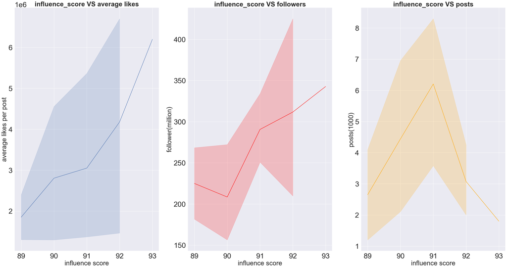

```python
data = insta.sort_values(by = ['influence_score'], ascending= False)#Sort data with infleunce score
data = data.head(20)#subset data with top 20 infleuncers with high influence score
sns.set(font_scale=3)#set font size
f, axes = plt.subplots(1, 3)# plot the factors' plots toegther in order to gain better comparison
lineplot1 = sns.lineplot(y = data.avg_likes,x = data.influence_score,ax=axes[0])#plot lineplot
lineplot1.set_title("influence_score VS average likes",fontdict= { 'fontsize': 30,'fontweight':'bold'})#set title foor the plot
lineplot1.set_xlabel("influence score",fontdict={"fontsize":30})#set xlabel
lineplot1.set_ylabel("average likes per post",fontdict={"fontsize":30})#set y label
lineplot2 = sns.lineplot(y = data['followers(m)'],x = data.influence_score,color='red',ax=axes[1])
lineplot2.set_title("influence_score VS followers",fontdict= { 'fontsize': 30,'fontweight':'bold'})#set title
lineplot2.set_xlabel("influence score",fontdict={"fontsize":30})#set xlabel
lineplot2.set_ylabel("follower(million)",fontdict={"fontsize":30})#set y label
lineplot3 = sns.lineplot(y = data['posts(k)'],x = data.influence_score,color='orange',ax=axes[2]) #plot lineplot
lineplot3.set_title("influence_score VS posts",fontdict= { 'fontsize': 30,'fontweight':'bold'})#set title
lineplot3.set_xlabel("influence score",fontdict={"fontsize":30})#set xlabel
lineplot3.set_ylabel("posts(1000)",fontdict={"fontsize":30})#set y label
```

Compare with these three plots, we can most relevant factor is average likes for each post. The second is followers. At that time, we can conclude that the most important factor to become a success internet influencer is to attract audiences in order to earn more postivie interactions like likes and with the average likes, We will gain more followers. No matter how much posts, the quality of post is the most important.

As we can see, interactions play one of the most important factors for internet influencer, I want to predict the popularity of influencers and predict their popularity in the future. Since ad salers need to enlarge their benefits so that they need to take a survey of internet influencers' capacities and influence score. At this time, I decided to use 60days engage rate and new average like post to predict the popularity among these instagram influencers.

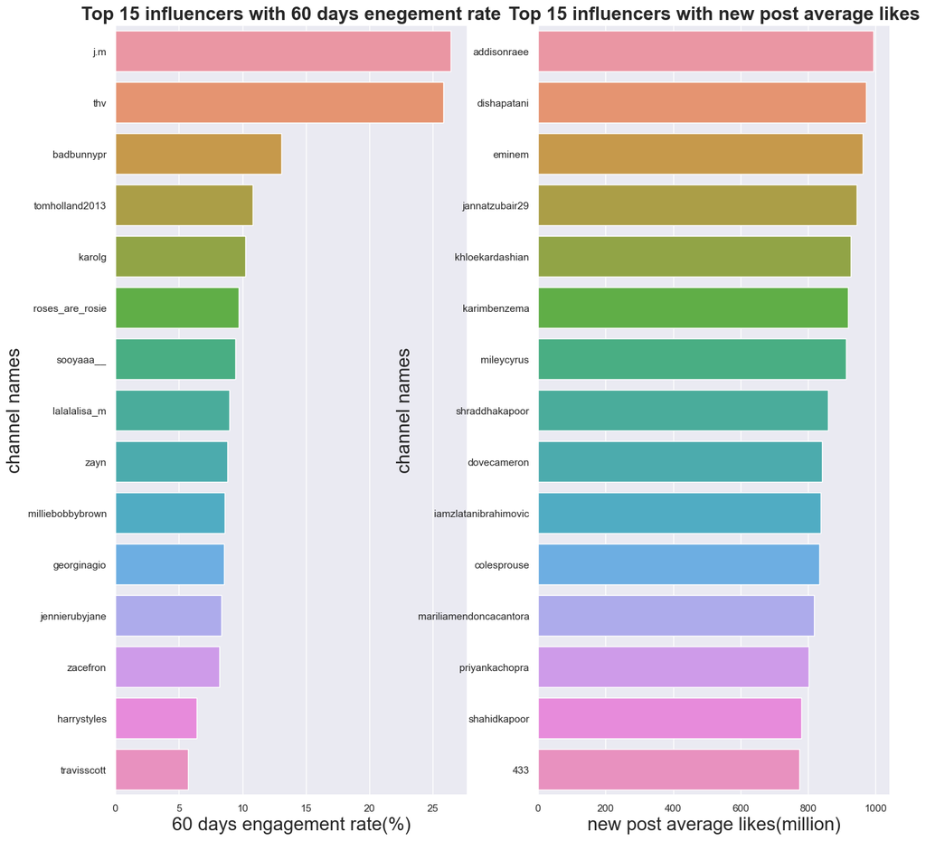

```python
data = insta.sort_values(by = ['X60_day_eng_rate(%)'], ascending= False)#Sort data with 60 day engagement rate
data = data.head(15)#subset data with top 15 infleuncers with high influence score
f, axes = plt.subplots(1, 2)# plot the factors' plots toegther in order to gain better comparison

barplot1 = sns.barplot(y=data["channel_info"], x = data['X60_day_eng_rate(%)'],ax=axes[0])#create the barplot with 60 day engagement rate
barplot1.set_title("Top 15 influencers with 60 days enegement rate",fontdict= { 'fontsize': 20,'fontweight':'bold'})#set title
barplot1.set_xlabel("60 days engagement rate(%)",fontdict= { 'fontsize': 20})#set xlabel
barplot1.set_ylabel("channel names",fontdict= { 'fontsize': 20})#set y label
data1 = insta.sort_values(by = ['new_post_avg_like(m)'], ascending= False)#Sort data with new post average likes
data1 = data1.head(15)#subset data with top 15 infleuncers with high new post average likes
barplot2 = sns.barplot(y=data1["channel_info"], x = data1['new_post_avg_like(m)'],ax=axes[1])#create the barplot with new post average likes
barplot2.set_title("Top 15 influencers with new post average likes",fontdict= { 'fontsize': 20,'fontweight':'bold'})#set title
barplot2.set_xlabel("new post average likes(million)",fontdict= { 'fontsize': 20})#set x label
barplot2.set_ylabel("channel names",fontdict= { 'fontsize': 20})#set y label
```

As we can see in the two plots, there are few similar channel names between these two plots. But ad salers can use these two plot to compare influencers in order to gain their benefits.

# Twitter API in Python

```python
tweetfreq = pd.read_csv("/Users/yangyilin/Desktop/anly-501-project-YilinYang2000-1/data/00-raw-data/wordfreqpython.csv")
tweetfreq
```

|  | Unnamed: 0 | words | counts |
| --- | --- | --- | --- |
| 0 | 0 | rt | 568 |
| 1 | 1 | relyanceai | 538 |
| 2 | 2 | action | 5 |
| 3 | 3 | california | 78 |
| 4 | 4 | attorney | 47 |
| ... | ... | ... | ... |
| 729 | 729 | hasgeek | 293 |
| 730 | 730 | enumberkcafmnumbera | 223 |
| 731 | 731 | tejasipanjiar | 646 |
| 732 | 732 | excited | 237 |
| 733 | 733 | come | 104 |

734 rows × 3 columns

From the frequency plot, I want to use wordcloud to make the histgram more straightforward to visualize.

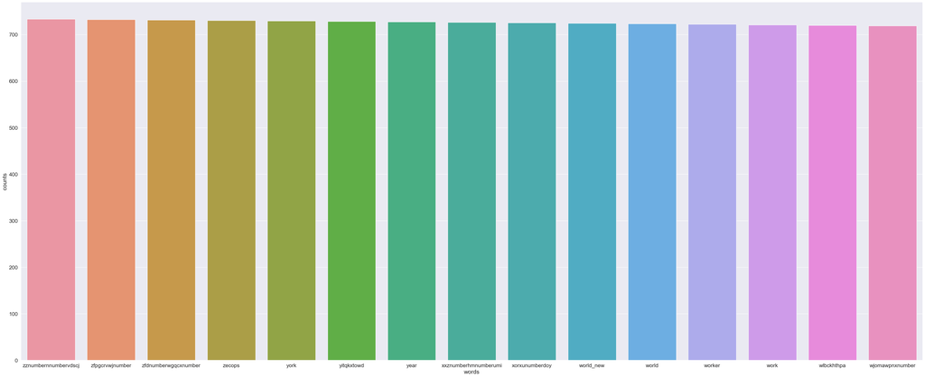

```python
data = tweetfreq.sort_values(by=['counts'],ascending=False)#sort the dataset
data = data.head(15)#subset the dataset
sns.set(rc = {'figure.figsize':(50,20)})#set plot size
sns.set(font_scale=1.5)#set font size
sns.barplot(x=data.words,y=data.counts)#use bar plot to plot the 10 most frequency words
```

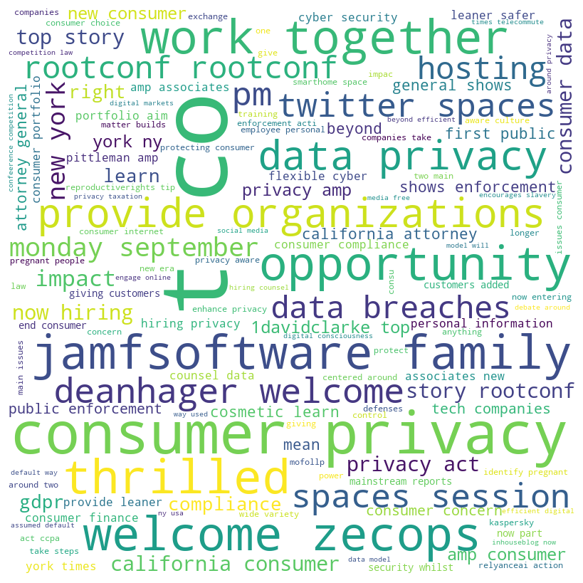

```python
# importing all necessary modules
from wordcloud import WordCloud, STOPWORDS
import matplotlib.pyplot as plt
import pandas as pd

# Reads 'Youtube04-Eminem.csv' file
df = pd.read_csv(r"/Users/yangyilin/Desktop/anly-501-project-YilinYang2000-1/data/00-raw-data/twitterpython.csv")

comment_words = ''
w = WordCloud()
stop_words = list(w.stopwords)
custom_stop_words = ['https', 'rt']#remove stop words
stopwords = set(stop_words + custom_stop_words)

# iterate through the csv file
for val in df.text:

    # typecaste each val to string
    val = str(val)

    # split the value
    tokens = val.split()

    # Converts each token into lowercase
    for i in range(len(tokens)):
        tokens[i] = tokens[i].lower()

    comment_words += " ".join(tokens)+" "

wordcloud = WordCloud(width = 800, height = 800,
                background_color ='white',
                stopwords = stopwords,
                min_font_size = 10).generate(comment_words)

# plot the WordCloud image
plt.figure(figsize = (8, 8), facecolor = None)
plt.imshow(wordcloud)
plt.axis("off")
plt.tight_layout(pad = 0)

plt.show()
```

From the wordcloud shows, we can clearly see several factors that affect consumers' privacy, it is easier for me to discuss from wordcloud than to the dataframes with a lot of texts

## Sentiment Analysis in Python

Through the data cleaning tab, I used sentiment analysis to clean the text datasets and classified each sentence. At this time, I plan to plot the results by using matplotlib and seaborn.

```python
tweetscore = pd.read_csv("/Users/yangyilin/Desktop/anly-501-project-YilinYang2000-1/data/00-raw-data/pytweetscore.csv")
tweetresult = pd.read_csv("/Users/yangyilin/Desktop/anly-501-project-YilinYang2000-1/data/00-raw-data/pytweetresult.csv")#import dataset
```

```python
tweetscore.head()
```

|  | Unnamed: 0 | text | neg | neu | pos | compound |
| --- | --- | --- | --- | --- | --- | --- |
| 0 | 0 | RT @relyanceai: Action by California Attorney ... | 0.0 | 1.000 | 0.000 | 0.0000 |
| 1 | 1 | Join @IDology and @AiteNovarica on October 12t... | 0.0 | 0.959 | 0.041 | 0.2960 |
| 2 | 2 | RT @relyanceai: Action by California Attorney ... | 0.0 | 0.970 | 0.030 | 0.2960 |
| 3 | 3 | Action by California Attorney General Shows En... | 0.0 | 0.943 | 0.057 | 0.7506 |
| 4 | 4 | RT @deanhager: Welcome @ZecOps to the @JamfSof... | 0.0 | 0.889 | 0.111 | 0.9370 |

```python
tweetresult.head()
```

|  | Unnamed: 0 | text | result | scores |
| --- | --- | --- | --- | --- |
| 0 | 0 | RT @relyanceai: Action by California Attorney ... | Neutral | 100.0 |
| 1 | 1 | Join @IDology and @AiteNovarica on October 12t... | Positive | 6.6 |
| 2 | 2 | RT @relyanceai: Action by California Attorney ... | Neutral | 100.0 |
| 3 | 3 | Action by California Attorney General Shows En... | Positive | 10.7 |
| 4 | 4 | RT @deanhager: Welcome @ZecOps to the @JamfSof... | Positive | 34.6 |

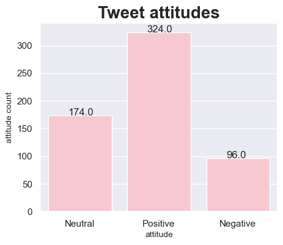

```python
sns.set(rc={'figure.figsize':(5,4)})
hist1 = sns.countplot(tweetresult.result,color = "pink")#create a histram of attitudes count
for p in hist1.patches:
   hist1.annotate('{:.1f}'.format(p.get_height()), (p.get_x()+0.25, p.get_height()+0.01))#give each bin a number to visulise clearly

hist1.set_title("Tweet attitudes",fontdict= { 'fontsize': 20,'fontweight':'bold'})#set title
hist1.set_xlabel("attitude",fontdict= { 'fontsize': 10})#set x label
hist1.set_ylabel("attitude count",fontdict= { 'fontsize': 10})#set y label
plt.show()
```

Now I want to use pie chart to clear show the distribution of each attitude.

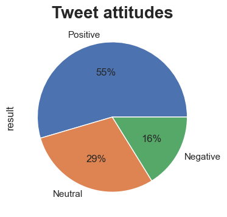

```python
pie1 = tweetresult.result.value_counts().plot(kind = "pie",autopct='%1.0f%%') #create pie plot
pie1.set_title("Tweet attitudes",fontdict= { 'fontsize': 20,'fontweight':'bold'}) #set title
```

Through this plot, we can clearly see the count of different attitudes through the plot. As we can see, most users have positive attitude on customer privacy, But there are a lot of users have neutural and negative attitudes of customer privacy.

# Twitter API in R

At this time, I still want to use wordcloud to compare platforms mentioned in twitter in order to make my results more straightforward and easier to understnad.

```python
library(selectr)
library(rvest)
library(xml2)
library(wordcloud2) # for generating really cool looking wordclouds
library(tm) # for text minning
library(dplyr) # loads of fun stuff including piping
library(ROAuth)
library(jsonlite)
library(httpuv)
library("tm")
library("SnowballC")
library("wordcloud")
library(wordcloud)
library("RColorBrewer")
suppressWarnings(expr)#ignore warning
options(warn=-1)
```

```
function (expr)
{
    enexpr(expr)
}
```

```python
d <- read.csv("/Users/yangyilin/Desktop/anly-501-project-YilinYang2000-1/data/00-raw-data/twittertm.csv")
```

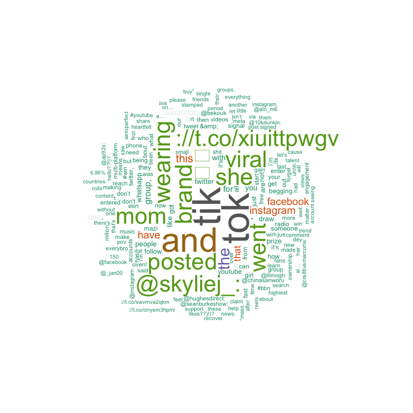

```python
#Gather a wordcloud

wordcloud(words = d$word,
          freq = d$freq,
          min.freq = 1,
          max.words = 200,
          random.order = FALSE,
          rot.per = 0.35,
          colors = brewer.pal(8, "Dark2"),
          widgetsize =c("1000","1000"))
```

As we can see in the plot, tiktok is the most popular talk in the twitter. Then we can find the instagram. Nowadays, tik-tok become more and more popular among the world. We can clearly see the popularity of it